# Analisis de Meteoritos

Lucas León González

La base de datos `meteoritos` contiene información de impactos de meteoritos y su fuente es la NASA. Incluye información sobre más de 45.000 meteoritos, incluyendo su nombre, ubicación, masa y año de impacto.

### **Parte 1**

**Pregunta:** *¿Cuál es la distribución geográfica de los meteoritos y donde cayeron los más pesados?*

**Introducción:** *La caída de meteoritos ha sido un fenómeno de interés científico y cultural a lo largo de la historia. La distribución geográfica y las características físicas de estos cuerpos celestes nos proporcionan información valiosa sobre su origen, trayectoria y las condiciones de impacto en la Tierra. Este análisis busca responder a dos preguntas fundamentales: ¿Dónde se distribuyen geográficamente los meteoritos y en qué regiones se encuentran los de mayor masa? Para ello, utilizamos una base de datos proporcionada por la NASA, que contiene más de 45.000 registros, incluyendo detalles como el nombre, la masa, el año de impacto y la ubicación geográfica (latitud y longitud) de cada meteorito. Esta base de datos es valiosa para entender la distribución de meteoritos en nuestro planeta.* *En respuesta a las preguntas anteriormente mencionadas, se utilizarán las variables de masa, latitud y longitud del conjunto de datos. Se explorará cómo la masa de los meteoritos varía en diferentes ubicaciones y se identificarán las áreas con meteoritos más grandes.*

**Enfoque:** *Empleamos herramientas del paquete ggplot2 de R para visualizar los datos de manera clara y comprensible. Para ello, se diseñaron dos tipos de gráficos:*

*Gráfico de dispersión: Representa cada meteorito en función de su ubicación geográfica, usando coordenadas de latitud y longitud. El tamaño y el color de los puntos destacan la masa total de los meteoritos, diferenciando entre aquellos que superan un umbral de masa establecido (meteoritos grandes) y los que no (meteoritos pequeños).El uso de un gráfico de dispersión es apropiado aquí porque facilita la identificación de patrones de ubicación en relación con la masa.*

*Mapa de calor: Muestra la densidad de impactos de meteoritos en distintas regiones del mundo. Este gráfico destaca las zonas de mayor concentración geográfica mediante un gradiente de color. Este enfoque es útil para identificar patrones en la distribución de caídas registradas, revelando zonas con alta densidad de impactos y otras con menor frecuencia de registros.*

**Analisis:**

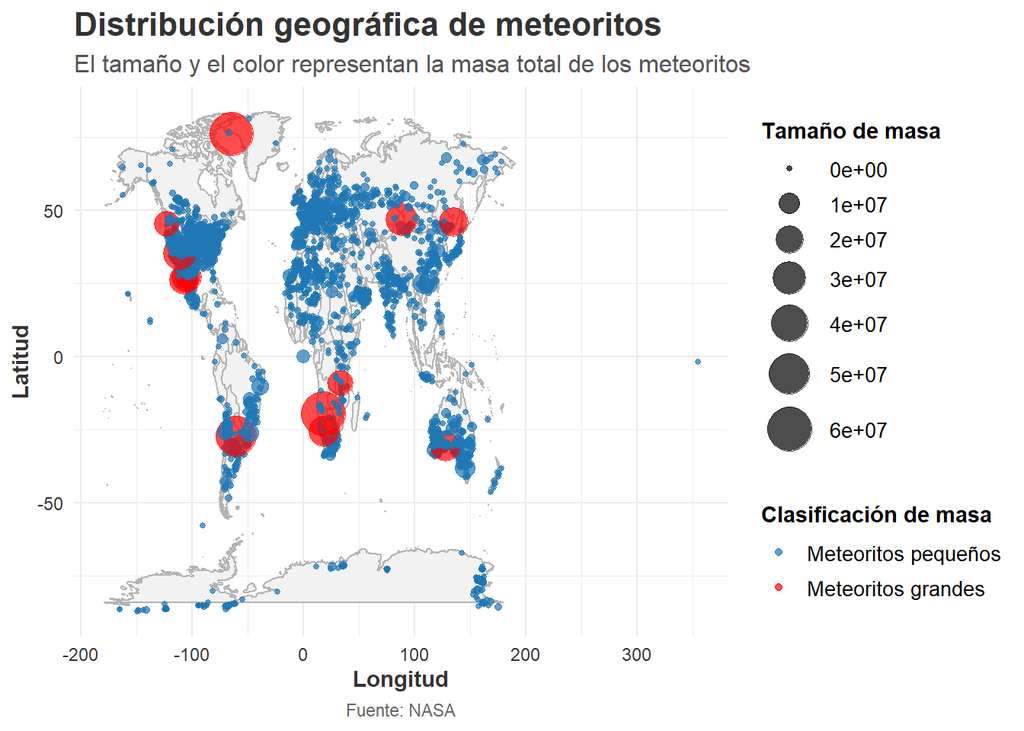

```r
# Define el umbral de masa para clasificar los meteoritos grandes
umbral_masa <- 1e+07

# Agrupa los meteoritos por latitud y longitud y calcula la masa total
meteoritos_agrupados <- meteoritos %>%
  group_by(lat, long) %>%
  summarise(total_masa = sum(mass, na.rm = TRUE), .groups = 'drop') %>%
  # Filtra filas con NA en lat o long
  filter(!is.na(lat) & !is.na(long))

# Crea el mapa base y superpone los puntos de meteoritos
ggplot() +
  # Agrega el mapa base con contornos de países
  borders("world", colour = "gray70", fill = "gray95") +
  # Superpone los puntos de meteoritos, con tamaño y color basados en la masa
  geom_point(data = meteoritos_agrupados,
             aes(x = long, y = lat, size = total_masa, color = total_masa > umbral_masa),
             alpha = 0.7) +
  # Ajusta la paleta cromática para los meteoritos
  scale_color_manual(
    values = c("FALSE" = "#1f77b4", "TRUE" = "red"),  # Azul profundo y dorado
    labels = c("FALSE" = "Meteoritos pequeños", "TRUE" = "Meteoritos grandes")
  ) +
  scale_size_continuous(range = c(1, 10), guide = guide_legend(title = "Tamaño de masa")) +
  labs(
    title = "Distribución geográfica de meteoritos",
    subtitle = "El tamaño y el color representan la masa total de los meteoritos",
    x = "Longitud",
    y = "Latitud",
    color = "Clasificación de masa",
    caption = "Fuente: NASA"
  ) +
  theme_minimal() +
  theme(
    plot.title = element_text(face = "bold", size = 16, color = "#333333"),
    plot.subtitle = element_text(size = 12, color = "#555555"),
    plot.caption = element_text(hjust = 0.5, color = "#666666"),
    axis.text = element_text(color = "#333333"),
    axis.title = element_text(face = "bold", color = "#333333"),
    legend.position = "right",  # Cambia la posición de la leyenda
    legend.title = element_text(face = "bold"),
    legend.text = element_text(size = 10)
  )
```

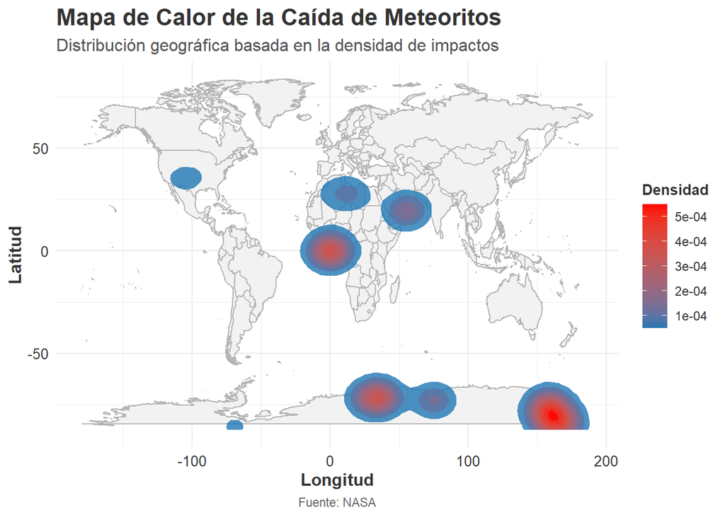

```r
# Cargar datos de meteoritos (modifica según tu nombre de dataframe y columnas)
meteoritos_limpios <- meteoritos %>%
  filter(!is.na(lat) & !is.na(long))  # Elimina filas con latitud o longitud faltantes

# Crear el mapa de calor
ggplot() +
  # Mapa base de los continentes
  borders("world", colour = "gray70", fill = "gray95") +
  # Crear mapa de calor usando stat_density_2d
  stat_density_2d(
    data = meteoritos_limpios,
    aes(x = long, y = lat, fill = after_stat(level)),
    geom = "polygon",
    contour = TRUE,
    alpha = 0.8  # Transparencia para mejor integración con el mapa base
  ) +
  # Escala de color personalizada basada en la paleta del primer gráfico
  scale_fill_gradient(
    low = "#1f77b4",  # Azul profundo
    high = "red",     # Rojo intenso
    guide = guide_colorbar(title = "Densidad")
  ) +
  labs(
    title = "Mapa de Calor de la Caída de Meteoritos",
    subtitle = "Distribución geográfica basada en la densidad de impactos",
    x = "Longitud",
    y = "Latitud",
    caption = "Fuente: NASA"
  ) +
  theme_minimal() +
  theme(
    plot.title = element_text(face = "bold", size = 16, color = "#333333"),
    plot.subtitle = element_text(size = 12, color = "#555555"),
    axis.title = element_text(face = "bold", size = 12, color = "#333333"),
    axis.text = element_text(size = 10, color = "#333333"),
    legend.position = "right",  # Mueve la leyenda al lado derecho
    legend.title = element_text(face = "bold", size = 10, color = "#333333"),
    legend.text = element_text(size = 9, color = "#333333"),
    plot.caption = element_text(hjust = 0.5, color = "#666666")
  )
```

### **Parte 2**

**Pregunta:** *¿La clase tienen alguna distribucion temporal?*

**Introducción:** *La caída de meteoritos no solo despierta interés por su impacto físico, sino también por las tendencias que se pueden observar a lo largo del tiempo. Analizar su distribución temporal nos proporciona información valiosa sobre cambios en la frecuencia de impactos, avances tecnológicos en su detección y factores históricos que influyen en su registro.* *En respuesta a esta pregunta, se analizará la cantidad de meteoritos registrados en intervalos de dos años para identificar tendencias a corto plazo, y se examinarán las variaciones en las principales clases de meteoritos por década para obtener una perspectiva histórica más amplia.*

**Enfoque:** *Para explorar la distribución temporal, utilizamos dos enfoques principales:*

*Tendencia bianual: Se agruparon los meteoritos por intervalos de dos años desde 1960 hasta 2012. Se visualizó la cantidad de meteoritos registrados en cada intervalo mediante un gráfico de líneas, destacando posibles tendencias de aumento o disminución en el tiempo.*

*Distribución de clases por década: Se analizaron las clases de meteoritos más observadas en cada década desde 1900. Se seleccionaron las diez clases con mayor número de registros y se representaron mediante un gráfico de barras apiladas, permitiendo observar cómo varía la composición de las clases a lo largo de las décadas.*

**Analisis:**

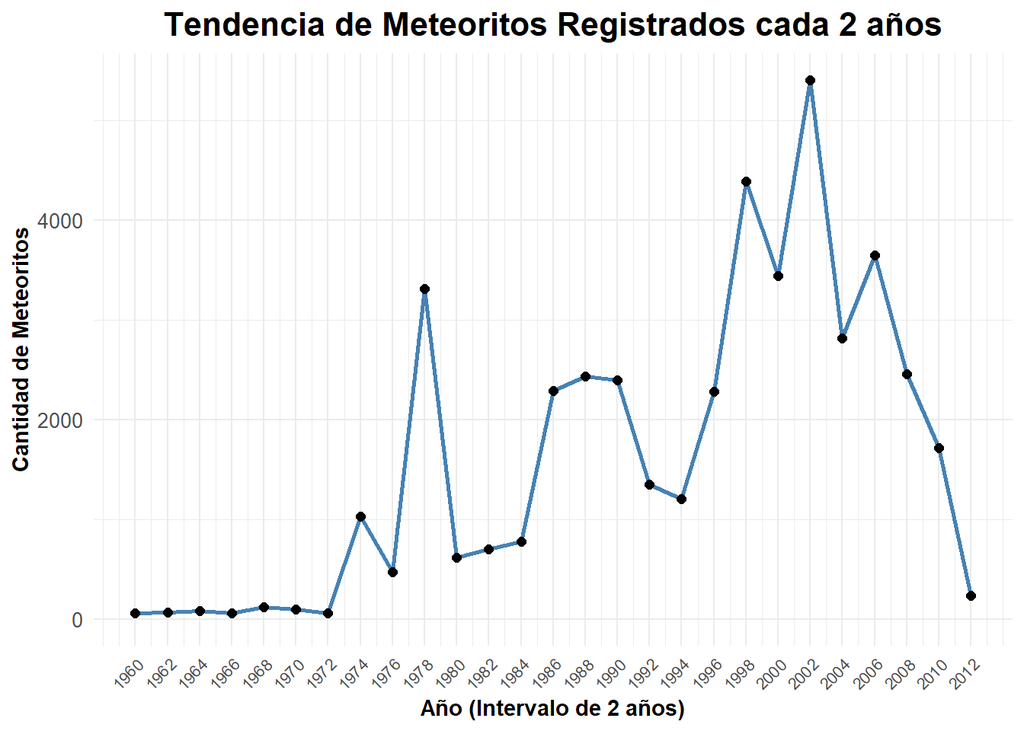

```r
# Filtrar los datos y calcular el intervalo de dos años
meteoritos_filtrados <- meteoritos %>%
  filter(!is.na(year) & year >= 1960 & year <= 2012) %>%
  mutate(intervalo = floor(year / 2) * 2)

# Contar la cantidad de meteoritos por intervalo de dos años
meteoritos_resumen <- meteoritos_filtrados %>%
  group_by(intervalo) %>%
  summarise(cantidad = n(), .groups = 'drop')

# Crear el gráfico de líneas
ggplot(meteoritos_resumen, aes(x = intervalo, y = cantidad)) +
  geom_line(color = "steelblue", linewidth = 1) +
  geom_point(color = "black", size = 2) +
  scale_x_continuous(
    name = "Año (Intervalo de 2 años)",
    breaks = seq(1960, 2012, by = 2),
    limits = c(1960, 2012)
  ) +
  scale_y_continuous(
    name = "Cantidad de Meteoritos",
    limits = c(0, max(meteoritos_resumen$cantidad, na.rm = TRUE))
  ) +
  labs(title = "Tendencia de Meteoritos Registrados cada 2 años") +
  theme_minimal() +
  theme(
    plot.title = element_text(face = "bold", size = 16, hjust = 0.5),
    axis.text.x = element_text(angle = 45, hjust = 1, size = 8),
    axis.text.y = element_text(size = 10),
    axis.title.x = element_text(face = "bold"),
    axis.title.y = element_text(face = "bold")
  )
```

[figure not shown]

```r
# Filtrar los datos y calcular la década
meteoritos_filtrados <- meteoritos %>%
  filter(!is.na(year) & year >= 1900 & year < 2100) %>%
  mutate(decada = floor(year / 10) * 10)

# Contar el número de meteoritos por década y clase
meteoritos_class <- meteoritos_filtrados %>%
  group_by(decada, class) %>%
  summarise(count = n(), .groups = "drop")

# Seleccionar solo las clases con más observaciones (top 10)
top_classes <- meteoritos_class %>%
  group_by(class) %>%
  summarise(total_count = sum(count), .groups = "drop") %>%
  top_n(10, total_count) %>%
  pull(class)

# Filtrar los datos para incluir solo las clases principales
meteoritos_top_classes <- meteoritos_class %>%
  filter(class %in% top_classes)


# Crear una paleta de colores personalizada con tonalidades más suaves de azul y rojo
colores_personalizados <- c(
  "#1f77b4",  # Azul profundo
  "red",  # Rojo intenso
  "#9ac9e6",   # Azul claro
  "#e68985",   # Rojo claro
  "#7ea1cd",   # Azul tenue
  "#e56a59",   # Rojo anaranjado
  "#aad4f5",   # Azul muy claro
  "#ffb3ab",   # Rosa pálido
  "#a8c9e7",   # Azul pálido
  "#f1c1b7"    # Rosa suave
)

# Crear el gráfico de barras agrupado por década
ggplot(meteoritos_top_classes, aes(x = factor(decada), y = count, fill = class)) +
  geom_bar(stat = "identity", position = "stack") +
  labs(
    title = "Distribución de las Clases Principales de Meteoritos",
    subtitle = "Top 10 clases de meteoritos con más observaciones desde 1800",
    x = "Década",
    y = "Número de Observaciones",
    fill = "Clase de Meteorito"
  ) +
  scale_fill_manual(values = colores_personalizados) + # Usar la paleta de colores personalizada
  theme_minimal() +
  theme(
    plot.title = element_text(face = "bold", size = 16, hjust = 0.5, color = "#333333"),
    plot.subtitle = element_text(size = 12, hjust = 0.5, color = "#555555"),
    axis.text.x = element_text(angle = 45, hjust = 1, size = 9, color = "#333333"),
    axis.text.y = element_text(size = 10, color = "#333333"),
    axis.title.x = element_text(face = "bold", color = "#333333"),
    axis.title.y = element_text(face = "bold", color = "#333333"),
    legend.position = "right", # Mover la leyenda al lado derecho
    legend.title = element_text(face = "bold", size = 10, color = "#333333"),
    legend.text = element_text(size = 9, color = "#333333")
  )
```